# Coronavirus JHU

Maher Ali Rusho

2023-01-24

# Introduction

## Analysing COVID-19 Data with R

The COVID-19 pandemic has taken the world by storm. Every nation on earth has joined the fight against this vicious virus, and every little contribution matters. The Internet has also provided the means to effectively use statistical and analytic tools to study the disease and its spread, thereby helping us to understand the implications of the pandemic. Data analysis is an effective tool to study the spread of the virus. This article outlines how to analyse COVID-19 data using R.

Data analysis helps us to understand complex data, identify the trends of data growth, and predict values for some distant points. Exploration of data provides the means to identify the pattern of its distribution and to discover its statistical model. As COVID-19 data is available on many reliable websites, it is possible to explore it for different statistical data analyses and modelling.

The objective of this article is to give readers an idea of data analysis on use cases. Interested readers can initiate exploratory analysis on this data for further understanding and thereby contribute to the welfare of human beings during this pandemic.

### Data acquisition

There are many well documented and organised COVID-19 data repositories. For instance, the GitHub repository of Johns Hopkins University Centre for Systems Science and Engineering (JHUCSSE) is highly reliable and easily accessible. From the URL, one can collect the latest data on the worldwide spread of COVID-19. Readers can download or read the data directly from the URL.

```r
library(data.table)
df <- fread("https://raw.githubusercontent.com/CSSEGISandData/COVID-19/master/csse_covid_19_data/csse_covid_19_time_series/time_series_covid19_confirmed_global.csv")
df <- data.frame(df,header=TRUE,stringsAsFactors=FALSE)
```

### Preprocessing

Preprocessing of the acquired data is an essential step of data analysis. Proper processing helps us to organise data efficiently and reduces the chances of errors in the final exercise. Preprocessing also makes the data complete by filling in the missing data and removing odd values.

Here we shall check the data for NA and fill in the blank Province.State fields with Country.Region values. As it is a huge data set, we shall demonstrate the analysis on some selective countries, namely, China, India, Pakistan and Iran.

```r
library(dplyr)
df$Province.State <- sub("^$", NA, df$Province.State)
df <- transform(df, Province.State = ifelse(Province.State=="" | is.na(Province.State), Country.Region, Province.State))
#Replace all fields with 0 if the value is NA
df <- df %>% replace(.=="NA", 0) # replace with 0
df <- df[with(df, Country.Region %in% c("China","India","Pakistan","Iran")),]
```

### Analysis

Country-wise infection count: The data set contains the state-wise infection count of some countries. To have a country-wise count of infection on each date, it is necessary to make a group of all the states of a country. This can be done in different ways.

Here I have used the aggregate() function to perform this group-wise summation, as shown below:

```r
dfCountryGroupSum <- aggregate(df[,c(5:ncol(df))],by=list(Category=df$Country.Region),FUN=sum)
head(dfCountryGroupSum[dfCountryGroupSum$Category=="China" ,c(1:5)])
```

```
##   Category X1.22.20 X1.23.20 X1.24.20 X1.25.20
## 1    China      548      643      920     1406
```

```r
dfCountryGroupSum[dfCountryGroupSum$Category=="China" | dfCountryGroupSum$Category=="India",c(1:10)]
```

```
##   Category X1.22.20 X1.23.20 X1.24.20 X1.25.20 X1.26.20 X1.27.20 X1.28.20
## 1    China      548      643      920     1406     2075     2877     5509
## 2    India        0        0        0        0        0        0        0
##   X1.29.20 X1.30.20
## 1     6087     8141
## 2        0        1
```

```r
head(dfCountryGroupSum[dfCountryGroupSum$Category %in% c("China","India"),c(1:5)])
```

```
##   Category X1.22.20 X1.23.20 X1.24.20 X1.25.20
## 1    China      548      643      920     1406
## 2    India        0        0        0        0
```

The aggregated result is stored in a dataframe variable dfCountryGroupSum, and displayed with dataframe indexing with the corresponding variables and logical filtering.

Aggregate of total infection of each country: To get the aggregate of infection in each country, it is necessary to add all the date-wise infection counts. This is implemented here with apply(). The sum() function is mapped to each row from the second column to the last column of dataframe dfCountryGroupSum.

```r
dfCountryGroupSum$Total <- apply(dfCountryGroupSum[,c(2:ncol(dfCountryGroupSum))],1,sum,na.omit=T)
 head(dfCountryGroupSum[with(dfCountryGroupSum, Category %in% c("China","India")),c(1,ncol(dfCountryGroupSum))])
```

```
##   Category       Total
## 1    China   949975127
## 2    India 27209611068
```

```r
 View(dfCountryGroupSum)
```

## Trend analysis

Trend analysis is important for future projections. As the acquired data contains sufficient reliable day-wise information of confirmed infection cases, we can perform trend analysis using a time series.

For simplicity, I shall demonstrate the time series analysis on some selected records only.

```r
daterange <- colnames(df[,c(5:ncol(df))])
countrynames <- df$Country.Region
tdf <- data.frame(t(df),stringsAsFactors=FALSE)
tdf <- tdf[c(-1),]
colnames(tdf) <- countrynames
rownames(tdf)
```

[output not shown]

[output cut: 261 more lines]

```r
tdf$cdate <- as.Date(seq(as.Date("2020/1/22"), by = "day",length.out=nrow(tdf)),format = "%d/%b/%Y-%u")
class(tdf$cdate)
```

```
## [1] "Date"
```

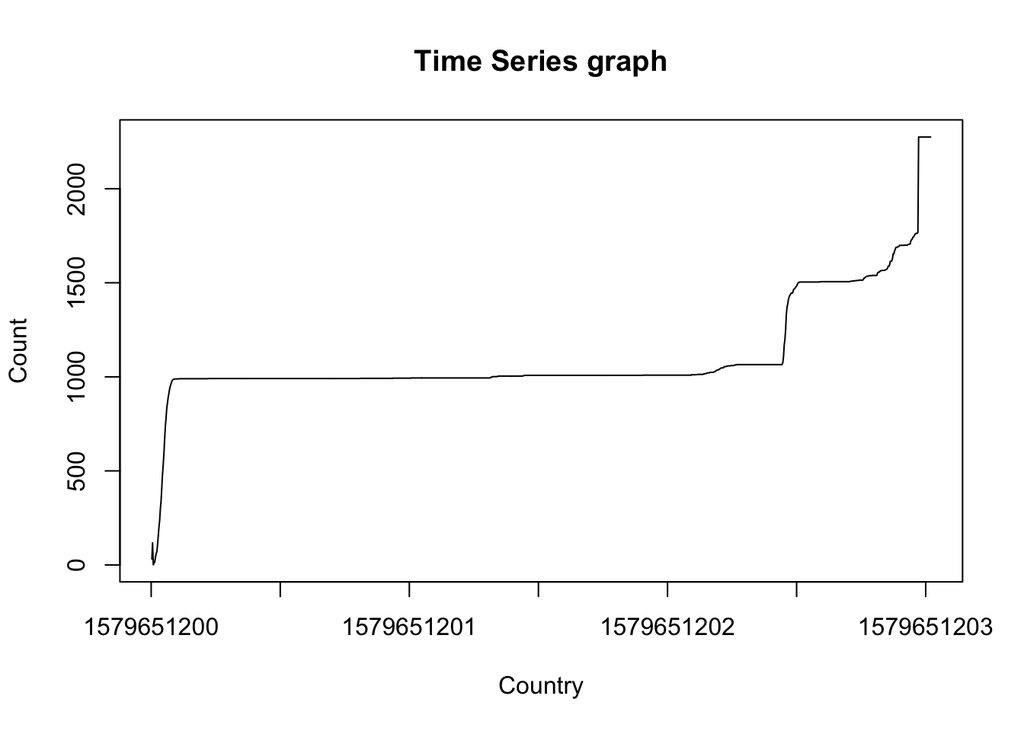

```r
tstdf <- ts(tdf$China,frequency=365, start=as.POSIXct(as.Date("2020/1/22")))
plot.ts(tstdf, xlab="Country", ylab="Count", main="Time Series graph")
```

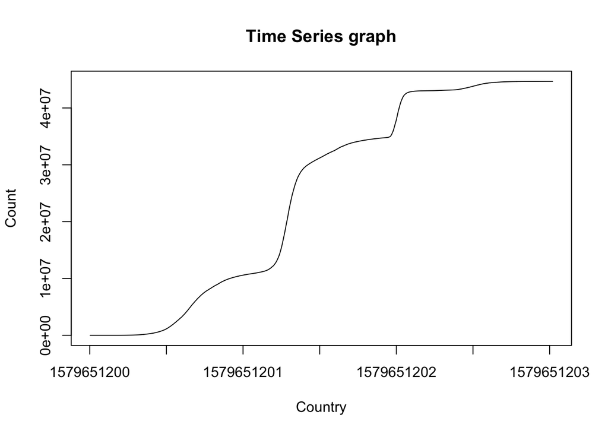

```r
tstdf <- ts(tdf$India,frequency=365, start=as.POSIXct(as.Date("2020/1/22")))
plot.ts(tstdf, xlab="Country", ylab="Count", main="Time Series graph")
```